# Serie A - Analisi esplorativa

### Introduzione

```r
rm(list = ls())
for (i in 1:10) gc()

#### SETUP ####
require(dplyr)
require(tidyr)
require(readr)
require(ggplot2)
require(stringi)
require(stringr)
require(corrplot)
require(gridExtra)

path_datasets <- "~/Google Drive/Tempo_Libero/"
path_functs <- "~/Documents/GitHub/data_science/AFSM/prog/functions/"

#### DATA IMPORT ####
df_in <- read.csv(paste0(path_datasets, "AFSM/Stats/00R_DT_campione_2015_2018.csv"),
                     sep = "|", stringsAsFactors = F)

classifica <- read.csv(paste0(path_datasets, "AFSM/Stats/classifica_serie_A_2014_2018.csv"),
                     sep = ";", stringsAsFactors = F)
```

### Analisi per squadra

Per prima cosa andiamo ad osservare come hanno performato le squadre. A parte il dominio della Juventus sara’ interessante andare ad approfondire la performance delle altre squadre, che da anni non riescono a vincere e si alternano tra il secondo e ultimo posto.

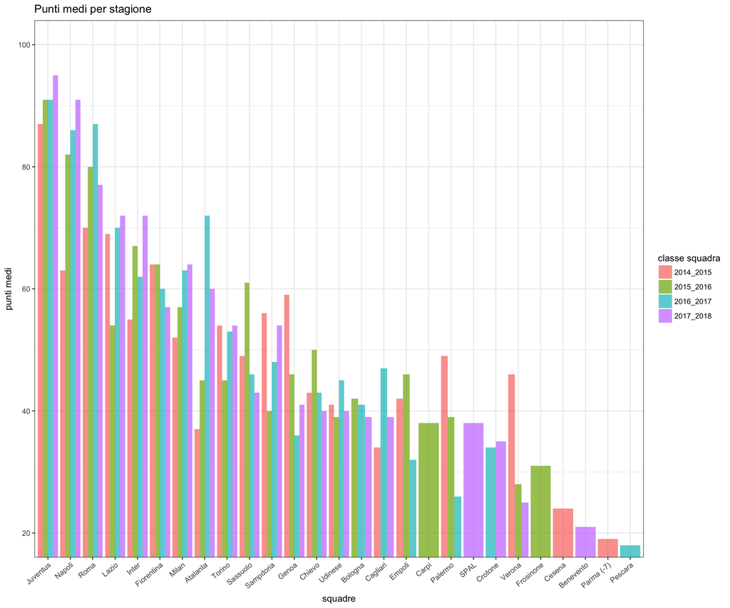

```r
classifica %>%
  ggplot(aes(reorder(Squadra, -Pt), Pt, fill = factor(Anno))) +
  geom_bar(stat = "identity", position = "dodge", alpha = 0.7) +
  theme_bw() +
  theme(axis.text.x = element_text(angle = 40, hjust = 1)) +
  labs(title = "Punti medi per stagione",
       x = "squadre", y = "punti medi",
       fill = "classe squadra") +
  coord_cartesian(ylim = c(20, 100))
```

La visione dei punti per anno ci puo’ suggerire quali sono i trend per ogni singola squadra. Capire se sono in un ciclo con trend positivo oppure negativo. Ad esempio il grafico sembra suggerire un trend positivo per il Milan mentre uno nettamente negativo per il sassuolo.

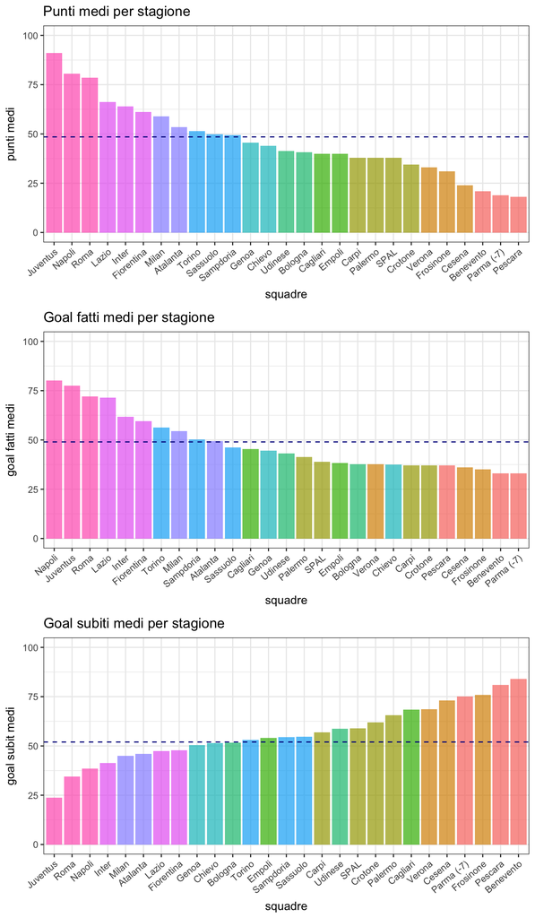

```r
class_aggr <- classifica %>%
  mutate(DR = as.numeric(DR)) %>%
  group_by(Squadra) %>%
  summarise(pos_media = mean(Pos),
            pt_media = mean(Pt),
            gf_media = mean(GF),
            gs_media = mean(GS),
            quote_media = mean(Quote)) %>%
  ungroup() %>%
  mutate(squadra_classe = cut(pt_media, breaks = quantile(pt_media, probs = seq(0,1,0.1)), labels = F, include.lowest = T))

gridExtra::grid.arrange(
  class_aggr %>%
  ggplot(aes(reorder(Squadra, -pt_media), pt_media, fill = factor(squadra_classe))) +
  geom_bar(stat = "identity", alpha = 0.7) +
  geom_hline(yintercept = median(classifica$Pt), linetype = 2, col = "darkblue") +
  theme_bw() +
  theme(axis.text.x = element_text(angle = 40, hjust = 1)) +
  labs(title = "Punti medi per stagione",
       x = "squadre", y = "punti medi",
       fill = "classe squadra") +
    guides(fill = FALSE) +
  coord_cartesian(ylim = c(0, 100)),
  class_aggr %>%
  ggplot(aes(reorder(Squadra, -gf_media), gf_media, fill = factor(squadra_classe))) +
  geom_bar(stat = "identity", alpha = 0.7) +
  geom_hline(yintercept = median(classifica$GF), linetype = 2, col = "darkblue") +
  theme_bw() +
  theme(axis.text.x = element_text(angle = 40, hjust = 1)) +
  labs(title = "Goal fatti medi per stagione",
       x = "squadre", y = "goal fatti medi",
       fill = "classe squadra") +
    guides(fill = FALSE) +
  coord_cartesian(ylim = c(0, 100)),
  class_aggr %>%
  ggplot(aes(reorder(Squadra, gs_media), gs_media, fill = factor(squadra_classe))) +
  geom_bar(stat = "identity", alpha = 0.7) +
  geom_hline(yintercept = median(classifica$GS), linetype = 2, col = "darkblue") +
  theme_bw() +
  theme(axis.text.x = element_text(angle = 40, hjust = 1)) +
  labs(title = "Goal subiti medi per stagione",
       x = "squadre", y = "goal subit medi",
       fill = "classe squadra") +
    guides(fill = FALSE) +
  coord_cartesian(ylim = c(0, 100)),
  ncol = 1)
```

### Analisi per giocatore

Analisi per giocatore per capire ancora una volta a livello molto basic quali sono le numeriche che bisogna aspettarsi. Primo step e’ osservare le distribuzioni per ruolo e per anno e andare a curiosare chi sono i piu’ produttivi degli ultimi anni

```r
distribuzione_var <- function(x, var_target) {

  x %>%
    rename_("var" = var_target) %>%
    summarise(N = n(),
              min = quantile(var, na.rm = T, probs = 0.0),
              q10 = quantile(var, na.rm = T, probs = 0.1),
              q20 = quantile(var, na.rm = T, probs = 0.2),
              q30 = quantile(var, na.rm = T, probs = 0.3),
              q40 = quantile(var, na.rm = T, probs = 0.4),
              q50 = quantile(var, na.rm = T, probs = 0.5),
              q60 = quantile(var, na.rm = T, probs = 0.6),
              q70 = quantile(var, na.rm = T, probs = 0.7),
              q80 = quantile(var, na.rm = T, probs = 0.8),
              q90 = quantile(var, na.rm = T, probs = 0.9),
              max = quantile(var, na.rm = T, probs = 1.0)) %>%
    mutate(variabile = var_target) %>%
    select(variabile, anno:max)

}

df_in %>%
  filter(pg > 10) %>%
  group_by(anno, r) %>%
  distribuzione_var(var_target = "gf_p")
```

| variabile | anno | r | N | min | q10 | q20 | q30 | q40 | q50 | q60 | q70 | q80 | q90 | max |
| --- | --- | --- | --- | --- | --- | --- | --- | --- | --- | --- | --- | --- | --- | --- |
| gf_p | 2015_2016 | A | 83 | 0 | 1 | 2 | 3 | 3 | 4.0 | 5.2 | 6.4 | 7.6 | 10.8 | 33 |
| gf_p | 2015_2016 | C | 140 | 0 | 0 | 0 | 1 | 1 | 1.0 | 2.0 | 3.0 | 4.0 | 5.0 | 9 |
| gf_p | 2015_2016 | D | 128 | 0 | 0 | 0 | 0 | 0 | 0.0 | 1.0 | 1.0 | 1.0 | 2.0 | 5 |
| gf_p | 2015_2016 | P | 23 | 0 | 0 | 0 | 0 | 0 | 0.0 | 0.0 | 0.0 | 0.0 | 0.0 | 0 |
| gf_p | 2016_2017 | A | 76 | 0 | 0 | 1 | 2 | 3 | 5.5 | 8.0 | 9.0 | 11.0 | 15.0 | 28 |
| gf_p | 2016_2017 | C | 144 | 0 | 0 | 0 | 1 | 1 | 1.0 | 2.0 | 3.0 | 4.0 | 5.7 | 14 |
| gf_p | 2016_2017 | D | 124 | 0 | 0 | 0 | 0 | 0 | 0.0 | 1.0 | 1.0 | 1.4 | 2.0 | 8 |
| gf_p | 2016_2017 | P | 25 | 0 | 0 | 0 | 0 | 0 | 0.0 | 0.0 | 0.0 | 0.0 | 0.0 | 0 |
| gf_p | 2017_2018 | A | 79 | 0 | 0 | 1 | 2 | 3 | 3.0 | 5.0 | 6.0 | 10.0 | 12.0 | 23 |
| gf_p | 2017_2018 | C | 134 | 0 | 0 | 0 | 1 | 1 | 2.0 | 2.0 | 3.0 | 4.0 | 6.0 | 12 |

[output cut: 2 more lines]

```r
df_in %>%
  filter(pg > 10) %>%
  group_by(anno, r) %>%
  distribuzione_var(var_target = "ass")
```

| variabile | anno | r | N | min | q10 | q20 | q30 | q40 | q50 | q60 | q70 | q80 | q90 | max |
| --- | --- | --- | --- | --- | --- | --- | --- | --- | --- | --- | --- | --- | --- | --- |
| ass | 2015_2016 | A | 83 | 0 | 0 | 0 | 1.0 | 1 | 2 | 2.0 | 3 | 3.0 | 4.0 | 9 |
| ass | 2015_2016 | C | 140 | 0 | 0 | 0 | 0.0 | 0 | 1 | 1.0 | 2 | 2.2 | 3.0 | 10 |
| ass | 2015_2016 | D | 128 | 0 | 0 | 0 | 0.0 | 0 | 0 | 0.2 | 1 | 1.0 | 2.0 | 4 |
| ass | 2015_2016 | P | 23 | 0 | 0 | 0 | 0.0 | 0 | 0 | 0.0 | 0 | 0.0 | 0.0 | 0 |
| ass | 2016_2017 | A | 76 | 0 | 0 | 0 | 1.0 | 1 | 2 | 2.0 | 3 | 4.0 | 5.0 | 11 |
| ass | 2016_2017 | C | 144 | 0 | 0 | 0 | 0.0 | 1 | 1 | 2.0 | 2 | 3.0 | 5.0 | 8 |
| ass | 2016_2017 | D | 124 | 0 | 0 | 0 | 0.0 | 0 | 0 | 1.0 | 1 | 2.0 | 2.7 | 6 |
| ass | 2016_2017 | P | 25 | 0 | 0 | 0 | 0.0 | 0 | 0 | 0.0 | 0 | 0.0 | 0.0 | 0 |
| ass | 2017_2018 | A | 79 | 0 | 0 | 0 | 0.4 | 1 | 1 | 2.0 | 2 | 3.0 | 5.0 | 10 |
| ass | 2017_2018 | C | 134 | 0 | 0 | 0 | 0.0 | 1 | 1 | 2.0 | 2 | 3.0 | 5.0 | 11 |

[output cut: 2 more lines]

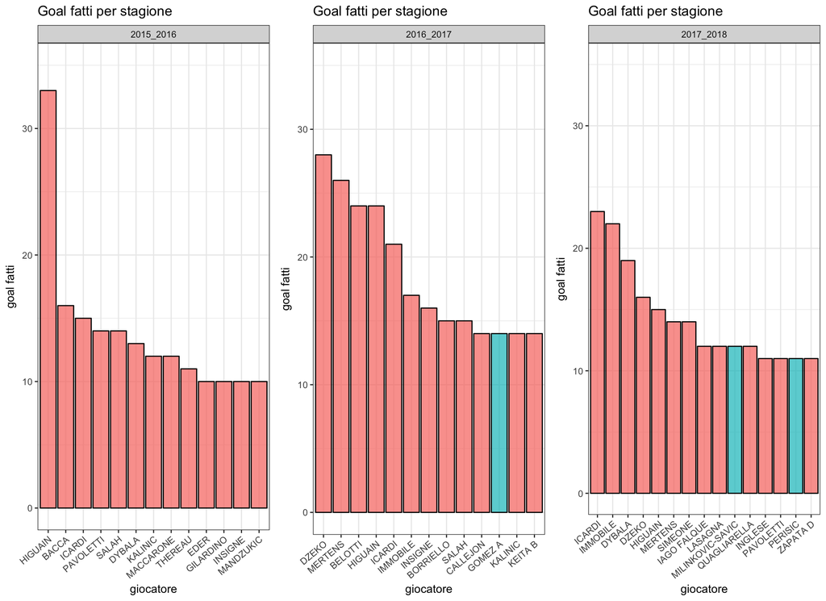

```r
grid.arrange(df_in %>%
  filter(pg > 5, r != "P", anno == "2015_2016") %>%
  top_n(13, wt = gf_p) %>%
  ggplot(aes(reorder(nome, -gf_p), gf_p, fill = r)) +
  geom_bar(stat = "identity", alpha = 0.7, col = "black") +
  theme_bw() +
  theme(axis.text.x = element_text(angle = 40, hjust = 1)) +
  labs(title = "Goal fatti per stagione",
       x = "giocatore", y = "goal fatti",
       fill = "ruolo") +
  facet_grid(.~anno, scales = "free_x") +
  guides(fill = FALSE) +
  coord_cartesian(ylim = c(0, 35)),
  df_in %>%
  filter(pg > 5, r != "P", anno == "2016_2017") %>%
  top_n(13, wt = gf_p) %>%
  ggplot(aes(reorder(nome, -gf_p), gf_p, fill = r)) +
  geom_bar(stat = "identity", alpha = 0.7, col = "black") +
  theme_bw() +
  theme(axis.text.x = element_text(angle = 40, hjust = 1)) +
  labs(title = "Goal fatti per stagione",
       x = "giocatore", y = "goal fatti",
       fill = "ruolo") +
  facet_grid(.~anno, scales = "free_x") +
  guides(fill = FALSE) +
  coord_cartesian(ylim = c(0, 35)),
  df_in %>%
  filter(pg > 5, r != "P", anno == "2017_2018") %>%
  top_n(13, wt = gf_p) %>%
  ggplot(aes(reorder(nome, -gf_p), gf_p, fill = r)) +
  geom_bar(stat = "identity", alpha = 0.7, col = "black") +
  theme_bw() +
  theme(axis.text.x = element_text(angle = 40, hjust = 1)) +
  labs(title = "Goal fatti per stagione",
       x = "giocatore", y = "goal fatti",
       fill = "ruolo") +
  facet_grid(.~anno, scales = "free_x") +
  guides(fill = FALSE) +
  coord_cartesian(ylim = c(0, 35)),
  ncol = 3)
```

Dovendo sintetizzare la peformance di un giocatore non si puo’ non passare dal fanta voto. Questa misura comprende i goal e assist fatti scontati dalle penalita’.

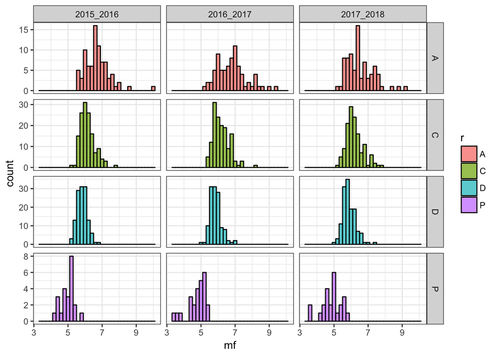

```r
df_in %>%
  filter(pg > 10) %>%
  ggplot(aes(mf, fill = r)) +
  geom_histogram(binwidth = 0.2, col = "black", alpha = 0.7) +
  facet_grid(r~anno, scales = "free_y")+
  theme_bw()
```

Ragionamenti sparsi ipotesi: default = pg < 15 & mf < quantile(mf, probs = 0.75)

```r
df_in_d = df_in %>%
  group_by(r) %>%
  mutate(status = ifelse(pg < 15 & mf < quantile(mf, probs = 0.75), 1, 0)) %>%
  ungroup()

df_in_d_train <- df_in_d %>% filter(anno != "2017_2018")

df_in_d_train %>%
  group_by(r) %>%
  summarise(td = sum(status)/n())
```

| r | td |
| --- | --- |
| A | 0.5431310 |
| C | 0.4735812 |
| D | 0.4838057 |
| P | 0.5962733 |